# Example Analysis

Jonathan A. Pedroza, PhD

7/25/2022

# Purpose

The purpose of this research project was to examine if access to recreational resources was associated with physical inactivity levels in counties within the western region of the United States. I was also interested in answering the question that violent crime rates in these counties would moderate the association between access to recreational resources and physical inactivity. Initially, multi-level models were conducted since the data is nested with counties (level 1) within states (level 2); however, due to the large amount of variation of counties within states I decided to account for differences between states by comparing physical inactivity levels of Western states (California was the reference group when dummy coded). Global Moran’s I tests were conducted, which showed significant autocorrelation, and Lagrange Multiplier tests were conducted to see which spatial regression would be the most appropriate for the data. Two spatial error models were conducted (based on Lagrange Multiplier test values) with access to recreational resources predicting physical inactivity while controlling for violent crime (2nd model would include violent crime as a moderator), median household income, percent of rurality in each county, air pollution values, percent of non-Latina/o/x population in each county, and state.

## Loading in Packages

Loading up all the packages and including my own theme for ggplot visuals.

```r
library(tidyverse)
library(sf)
library(psych)
library(tidycensus)
library(spdep)
library(spatialreg)
library(rgdal)
library(rgeos)
library(tmap)
library(inspectdf)
library(reactable)

options(scipen = 999)
theme_set(theme_light())

set.seed(123021)
```

## Including User-Defined Functions

```r
spatial_stand_coef <- function(object){
  object$model <- cbind(object$y, object$X)

  model <- as.matrix(object$model)
  model <- as.data.frame(model)

  b <- as.matrix(object$coefficients)
  sy <- sd(model[, 1])
  sx <- purrr::map_dbl(model[, -1], ~sd(.x))
  beta <- function(b, sx, sy){
    b*sx/sy
  }
  beta(b, sx, sy)
}


error_model_residuals <- function(data, object, listw, zero.policy = c(TRUE, FALSE, NULL), nsim = 9999, seed = 12345){
    visual <- ggplot(data = data, aes(x = object$fitted.values, y = object$residuals)) +
                geom_point() +
          geom_hline(yintercept = 0,
                     linetype = 2,
                     size = 1.25,
                     color = 'dodgerblue')

    set.seed(seed)
    moran_find <- moran.mc(object$residuals, listw = listw, zero.policy = zero.policy, nsim = nsim)

  statistics <- if(moran_find$statistic < 0){
    upper <- (1 - moran_find$p.value)
    upper*2

  } else{
    moran_find$p.value*2
  }
    return(list(visual, statistics))
}


jn_sem <- function(model, x, m, alpha = .05){
  library(stringi)

  b1 = model$coefficients[x]
  b3 = model$coefficients[stri_startswith_fixed(names(model$coefficients),
                                                paste0(x,":"))]

  se_b1 = model$rest.se[paste0("I(x - lambda * WX)", x)]
  se_b3 = model$rest.se[paste0("I(x - lambda * WX)", x, ":", m)]

  cov_b1b3 = vcov(model)[x, paste0(x, ":", m)]

  z_crit = qt(1-alpha/2, (nrow(model$tarX) - model$parameters - 1))
  # see Bauer & Curran, 2005
  a = z_crit^2 * se_b3^2 - b3^2
  b = 2 * (z_crit^2 * cov_b1b3 - b1 * b3)
  c = z_crit^2 * se_b1^2 - b1^2
  jn_final = c(
    (-b - sqrt(b^2 - 4 * a * c)) / (2 * a),
    (-b + sqrt(b^2 - 4 * a * c)) / (2 * a)
  )

  jn = sort(unname(jn_final))
  jn_min = jn[jn >= min(model$tarX[, paste0("I(x - lambda * WX)", m)])]

  jn_max = jn[jn <= max(model$tarX[, paste0("I(x - lambda * WX)", m)])]

  return(list(jn_min, jn_max))
}


theta_plot_sem <- function(model, x, m, alpha = .05, jn = FALSE) {
  require(dplyr)
  require(ggplot2)
  require(stringi)

  data = tibble(b1 = model$coefficients[x],
                b3 = model$coefficients[stri_startswith_fixed(names(model$coefficients),
                                                              paste0(x,":"))],
                # instead of model look for this
                z = quantile(model$tarX[, paste0("I(x - lambda * WX)", m)], seq(0,1,.01)),
                theta = b1 + z * b3,
                se_b1 = model$rest.se[paste0("I(x - lambda * WX)", x)],
                cov_b1b3 = vcov(model)[x, paste0(x, ":", m)],
                se_b3 = model$rest.se[paste0("I(x - lambda * WX)", x, ":", m)],

                se_theta = sqrt(se_b1^2 + 2 * z * cov_b1b3 + z^2 * se_b3^2),
                ci.lo_theta = theta + qt(alpha/2, (nrow(model$tarX) - model$parameters - 1))*se_theta,
                ci.hi_theta = theta + qt(1-alpha/2, (nrow(model$tarX) - model$parameters - 1))*se_theta)
  jn_plot1 <- if (jn) {
    jn_fun = jn_sem(model = model, x = x, m = m, alpha = alpha)[[1]]
    jn_lines = geom_vline(xintercept = jn_fun, linetype = 2)
    jn_regions = ifelse(length(jn_fun) == 0, "no significance regions", paste(round(jn_fun, 2), collapse = "; "))
    xlab = paste0(m, " (JN Significance Regions: ", jn_regions,")")
  }
  else {
    xlab = m
    jn_lines = NULL
  }

  jn_ggplot1 <- data %>%
                  ggplot(aes(z, theta, ymin = ci.lo_theta, ymax = ci.hi_theta)) +
                  geom_ribbon(alpha = .2) +
                  geom_line(color = "dodgerblue", size = 1) +
                  # ggtitle(paste("Conditional Effect of", x, "as function of", m)) +
                  geom_hline(yintercept = 0, linetype = 2) +
                  labs(x = xlab, y = expression(theta)) +
                  jn_lines

  jn_plot2 <- if (jn) {
    jn_fun = jn_sem(model = model, x = x, m = m, alpha = alpha)[[2]]
    jn_lines = geom_vline(xintercept = jn_fun, linetype = 2)
    jn_regions = ifelse(length(jn_fun) == 0, "no significance regions", paste(round(jn_fun, 2), collapse = "; "))
    xlab = paste0(m, " (JN Significance Regions: ", jn_regions,")")
  }
  else {
    xlab = m
    jn_lines = NULL
  }

  jn_ggplot2 <- data %>%
                  ggplot(aes(z, theta, ymin = ci.lo_theta, ymax = ci.hi_theta)) +
                  geom_ribbon(alpha = .2) +
                  geom_line(color = "dodgerblue", size = 1) +
                  # ggtitle(paste("Conditional Effect of", x, "as function of", m)) +
                  geom_hline(yintercept = 0, linetype = 2) +
                  labs(x = xlab, y = expression(theta)) +
                  jn_lines

  return(list(jn_ggplot1, jn_ggplot2))
}
```

## Loading County Health Rankings & Roadmaps (CHRR) Data

[Here](https://www.countyhealthrankings.org/explore-health-rankings/rankings-data-documentation) is the link to the dataset for 2021. More information about CHRR’s mission can be found [here](https://www.countyhealthrankings.org/). Data from 2021 has been saved in a github repo.

```r
county <- read_csv('https://raw.githubusercontent.com/jpedroza1228/dissertation/master/analytic_data/analytic_data2021.csv') %>%
  janitor::clean_names()
```

## 2020 Census Data Wrangling

```r
census_var <- c('P2_002N', #latino
                'P2_003N', #not_latino
                'P2_001N') #total

cen21 <- get_decennial(geography = 'county',
                       variables = census_var,
                       year = 2020,
                       survey = 'pl',
                       output = 'wide') %>%
  janitor::clean_names()

cen10 <- get_decennial(geography = 'county',
                       variables = "P013001",
                       year = 2010,
                       geometry = TRUE,
                       output = 'wide') %>%
  janitor::clean_names() %>%
  separate(col = name, into = c("county_name", "state_name"), sep = ", ") %>%
  mutate(state_name = str_to_lower(state_name),
         county_name = str_to_lower(county_name),
         state = recode(state_name, 'alabama' = 'AL','alaska' = 'AK','arizona' = 'AZ','arkansas' = 'AR',
                        'california' = 'CA','colorado' = 'CO','connecticut' = 'CT',
                        'delaware' = 'DE', 'district of columbia' = 'DC',
                        'florida' = 'FL',
                        'georgia' = 'GA',
                        'hawaii' = 'HI',
                        'idaho' = 'ID','illinois' = 'IL','indiana' = 'IN','iowa' = 'IA',
                        'kansas' = 'KS','kentucky' = 'KY',
                        'louisiana' = 'LA',
                        'maine' = 'ME','maryland' = 'MD','massachusetts' = 'MA','michigan' = 'MI','minnesota' = 'MN','mississippi' = 'MS','missouri' = 'MO','montana' = 'MT',
                        'nebraska' = 'NE','nevada' = 'NV','new hampshire' = 'NH','new jersey' = 'NJ','new mexico' = 'NM','new york' = 'NY','north carolina' = 'NC','north dakota' = 'ND',
                        'ohio' = 'OH','oklahoma' = 'OK','oregon' = 'OR',
                        'pennsylvania' = 'PA',
                        'rhode island' = 'RI',
                        'south carolina' = 'SC','south dakota' = 'SD',
                        'tennessee' = 'TN','texas' = 'TX',
                        'utah' = 'UT',
                        'vermont' = 'VT','virginia' = 'VA',
                        'washington' = 'WA','west virginia' = 'WV','wisconsin' = 'WI','wyoming' = 'WY',
                        'puerto rico' = "PR"))
```

```r
cen21 <- cen21 %>%
  separate(col = name, into = c("county_name", "state_name"), sep = ", ") %>%
  rename(latino = p2_002n,
         not_latino = p2_003n,
         total = p2_001n)

cen21 %>%
  group_by(state_name) %>%
  summarize(mean_latino = mean(latino),
            mean_nl = mean(not_latino)) %>%
  t()
```

```
##             [,1]          [,2]          [,3]          [,4]
## state_name  "Alabama"     "Alaska"      "Arizona"     "Arkansas"
## mean_latino "  3941.0000" "  1660.8000" "146150.2000" "  3424.6267"
## mean_nl     " 71048.2388" " 22785.5667" "330616.6000" " 36729.0267"
##             [,5]          [,6]          [,7]          [,8]
## state_name  "California"  "Colorado"    "Connecticut" "Delaware"
## mean_latino "268614.6897" " 19740.4688" " 77911.6250" " 34763.3333"
## mean_nl     "413078.8103" " 70473.8125" "372831.3750" "295219.3333"
##             [,9]                   [,10]         [,11]         [,12]
## state_name  "District of Columbia" "Florida"     "Georgia"     "Hawaii"
## mean_latino " 77652.0000"          " 85033.4328" "  7065.7673" " 27784.6000"
## mean_nl     "611893.0000"          "236432.0448" " 60304.7233" "263269.6000"
##             [,13]         [,14]         [,15]         [,16]
## state_name  "Idaho"       "Illinois"    "Indiana"     "Iowa"
## mean_latino "  5441.0682" " 22915.7843" "  6023.8152" "  2181.6768"
## mean_nl     " 36356.7955" "102697.0392" " 67731.9239" " 30044.2727"
##             [,17]         [,18]         [,19]         [,20]
## state_name  "Kansas"      "Kentucky"    "Louisiana"   "Maine"
## mean_latino "  3643.8381" "  1732.1167" "  5039.8281" "  1663.0625"
## mean_nl     " 24335.9714" " 35816.5167" " 67737.6250" " 83484.3750"
##             [,21]         [,22]           [,23]         [,24]
## state_name  "Maryland"    "Massachusetts" "Michigan"    "Minnesota"
## mean_latino " 30406.0417" " 63406.0714"   "  6800.2651" "  3972.8736"
## mean_nl     "226978.2917" "438730.8571"   "114613.3614" " 61619.0115"
##             [,25]         [,26]         [,27]         [,28]
## state_name  "Mississippi" "Missouri"    "Montana"     "Nebraska"
## mean_latino "  1283.1707" "  2635.3739" "   807.1250" "  2523.8172"
## mean_nl     " 34829.9878" " 50885.6087" " 18554.0357" " 18567.6237"
##             [,29]         [,30]           [,31]         [,32]
## state_name  "Nevada"      "New Hampshire" "New Jersey"  "New Mexico"
## mean_latino " 52368.0588" "  5945.4000"   " 95360.7143" " 30630.6364"
## mean_nl     "130256.2941" "131807.5000"   "346972.3333" " 33536.6970"
##             [,33]         [,34]            [,35]          [,36]
## state_name  "New York"    "North Carolina" "North Dakota" "Ohio"
## mean_latino " 63677.9355" " 11185.9600"    "   630.4151"  "  5923.9545"
## mean_nl     "262148.6613" " 93207.9200"    " 14069.4717"  "128160.6818"
##             [,37]         [,38]         [,39]          [,40]
## state_name  "Oklahoma"    "Oregon"      "Pennsylvania" "Puerto Rico"
## mean_latino "  6128.9740" " 16354.3611" " 15665.8955"  " 41654.3974"
## mean_nl     " 45291.1948" "101347.1944" "178404.2537"  "   472.1923"
##             [,41]          [,42]            [,43]          [,44]
## state_name  "Rhode Island" "South Carolina" "South Dakota" "Tennessee"
## mean_latino " 36420.2000"  "  7670.3913"    "   586.9848"  "  5044.0737"
## mean_nl     "183055.6000"  "103599.7174"    " 12847.3636"  " 67701.6105"
##             [,45]         [,46]         [,47]         [,48]
## state_name  "Texas"       "Utah"        "Vermont"     "Virginia"
## mean_latino " 45046.1299" " 16996.9655" "  1107.4286" "  6832.6992"
## mean_nl     " 69699.9528" " 95817.3793" " 44826.6429" " 58064.9925"
##             [,49]         [,50]           [,51]         [,52]
## state_name  "Washington"  "West Virginia" "Wisconsin"   "Wyoming"
## mean_latino " 27159.3077" "   633.2182"   "  6212.3611" "  2567.2174"
## mean_nl     "170412.0000" " 31979.8000"   " 75644.8333" " 22513.2609"
```

```r
cen21 <- cen21 %>%
  mutate(state_name = str_to_lower(state_name),
         county_name = str_to_lower(county_name),
         state = recode(state_name, 'alabama' = 'AL','alaska' = 'AK','arizona' = 'AZ','arkansas' = 'AR',
                        'california' = 'CA','colorado' = 'CO','connecticut' = 'CT',
                        'delaware' = 'DE', 'district of columbia' = 'DC',
                        'florida' = 'FL',
                        'georgia' = 'GA',
                        'hawaii' = 'HI',
                        'idaho' = 'ID','illinois' = 'IL','indiana' = 'IN','iowa' = 'IA',
                        'kansas' = 'KS','kentucky' = 'KY',
                        'louisiana' = 'LA',
                        'maine' = 'ME','maryland' = 'MD','massachusetts' = 'MA','michigan' = 'MI','minnesota' = 'MN','mississippi' = 'MS','missouri' = 'MO','montana' = 'MT',
                        'nebraska' = 'NE','nevada' = 'NV','new hampshire' = 'NH','new jersey' = 'NJ','new mexico' = 'NM','new york' = 'NY','north carolina' = 'NC','north dakota' = 'ND',
                        'ohio' = 'OH','oklahoma' = 'OK','oregon' = 'OR',
                        'pennsylvania' = 'PA',
                        'rhode island' = 'RI',
                        'south carolina' = 'SC','south dakota' = 'SD',
                        'tennessee' = 'TN','texas' = 'TX',
                        'utah' = 'UT',
                        'vermont' = 'VT','virginia' = 'VA',
                        'washington' = 'WA','west virginia' = 'WV','wisconsin' = 'WI','wyoming' = 'WY',
                        'puerto rico' = "PR"))
```

Loading in data on the population of each state and county that are Latina/o/x or non-Latina/o/x. This also included having state abbreviations since it will be easier to use for visualizations later. The purpose of including these variables is to see if counties with larger Latina/o/x populations have higher rates of physical inactivity. Data from 2010 was loaded as 2020 Census geometry data has not been updated in the `TidyCensus` package.

## Joining Census and CHRR Datasets

```r
county <- county %>%
  rename(state = state_abbreviation,
         county_name = name) %>%
  mutate(county_name = str_to_lower(county_name))

cen21 <- full_join(cen21, cen10)

data <- left_join(cen21, county, by = c("county_name", "state"))

data <- data %>%
  select(!ends_with("ci_low") &
         !ends_with("ci_high") &
         !ends_with("numerator") &
         !ends_with("denominator")) %>%
  mutate(state2 = state,
         region = recode(state2, "AL" = "South",
                         "AK" = "West",
                         "AZ" = "West",
                         "AR" = "South",
                         "CA" = "West",
                         "CO" = "West",
                         "CT" = "Northeast",
                         "DE" = "South",
                         "DC" = "Northeast",
                         "FL" = "South",
                         "GA" = "South",
                         "HI" = "West",
                         "ID" = "West",
                         "IL" = "Midwest",
                         "IN" = "Midwest",
                         "IA" = "Midwest",
                         "KS" = "Midwest",
                         "KY" = "South",
                         "LA" = "South",
                         "ME" = "Northeast",
                         "MD" = "South",
                         "MA" = "Northeast",
                         "MI" = "Midwest",
                         "MN" = "Midwest",
                         "MS" = "South",
                         "MO" = "Midwest",
                         "MT" = "West",
                         "NE" = "Midwest",
                         "NV" = "West",
                         "NH" = "Northeast",
                         "NJ" = "Northeast",
                         "NM" = "West",
                         "NY" = "Northeast",
                         "NC" = "South",
                         "ND" = "Midwest",
                         "OH" = "Midwest",
                         "OK" = "South",
                         "OR" = "West",
                         "PA" = "Northeast",
                         "RI" = "Northeast",
                         "SC" = "South",
                         "SD" = "Midwest",
                         "TN" = "South",
                         "TX" = "South",
                         "UT" = "West",
                         "VT" = "Northeast",
                         "VA" = "South",
                         "WA" = "West",
                         "WV" = "South",
                         "WI" = "Midwest",
                         "WY" = "West",
                         "PR" = "Outside"))


model_data <- data %>%
  select(geoid:release_year,
         adult_smoking_raw_value:alcohol_impaired_driving_deaths_raw_value,
         uninsured_raw_value:ratio_of_population_to_mental_health_providers,
         flu_vaccinations_raw_value,
         unemployment_raw_value,
         children_in_poverty_raw_value,
         social_associations_raw_value:injury_deaths_raw_value,
         air_pollution_particulate_matter_raw_value,
         drinking_water_violations_raw_value,
         driving_alone_to_work_raw_value,
         long_commute_driving_alone_raw_value,
         diabetes_prevalence_raw_value:drug_overdose_deaths_raw_value,
         motor_vehicle_crash_deaths_raw_value,
         insufficient_sleep_raw_value:ratio_of_population_to_primary_care_providers_other_than_physicians,
         median_household_income_raw_value,
         children_eligible_for_free_or_reduced_price_lunch_raw_value,
         homicides_raw_value,
         suicides_raw_value:crude_suicide_rate,
         firearm_fatalities_raw_value,
         juvenile_arrests_raw_value,
         traffic_volume_raw_value,
         homeownership_raw_value,
         broadband_access_raw_value,
         population_raw_value:percent_rural_raw_value,
         region,
         geometry) %>%
  mutate(county = str_replace_all(county_name, pattern = " county", replacement = ""))
```

This step included creating a region variable and removed any columns that were not needed for analyses.

## Finalizing Model Data

```r
model_data <- model_data %>%
  mutate(geoid = as.factor(geoid),
         county_name = as.factor(county_name),
         state_name = as.factor(state_name),
         state = as.factor(state),
         release_year = as.factor(release_year),
         region = as.factor(region),
         state_fips_code = as.factor(state_fips_code),
         county_fips_code = as.factor(county_fips_code),
         x5_digit_fips_code = as.factor(x5_digit_fips_code),
         drinking_water_violations_raw_value = as.factor(drinking_water_violations_raw_value),
         county = as.factor(county)) %>%
  mutate_if(is.character, as.numeric)

model_data <- model_data %>%
  mutate_if(is.numeric, ~ifelse(is.na(.), median(., na.rm = TRUE), .)) %>%
  filter(region != "Outside") %>%
  mutate(region = relevel(region, ref = "West"),
         state = relevel(state, ref = "CA"))

west_data <- model_data %>%
  filter(region == 'West',
         state != 'HI',
         state != 'AK')

west_data <- west_data %>%
  rename(food_envir_index = food_environment_index_raw_value,
         social_associations = social_associations_raw_value,
         violent_crime = violent_crime_raw_value,
         injury_death = injury_deaths_raw_value,
         air_pollution = air_pollution_particulate_matter_raw_value,
         homicide = homicides_raw_value,
         suicide = suicides_raw_value,
         suicide_rate = crude_suicide_rate,
         gun_death = firearm_fatalities_raw_value,
         juvenile_arrest = juvenile_arrests_raw_value,
         traffic_volume = traffic_volume_raw_value,
         population = population_raw_value) %>%
  mutate(smoking = adult_smoking_raw_value*100,
         obesity = adult_obesity_raw_value*100,
         inactivity = physical_inactivity_raw_value*100,
         access = access_to_exercise_opportunities_raw_value*100,
         excess_drink = excessive_drinking_raw_value*100,
         drunk_drive_death = alcohol_impaired_driving_deaths_raw_value*100,
         uninsured = uninsured_raw_value*100,
         pcp = primary_care_physicians_raw_value*100,
         dentist = dentists_raw_value*100,
         mental_provider = mental_health_providers_raw_value*100,
         flu_vaccine = flu_vaccinations_raw_value*100,
         unemployment = unemployment_raw_value*100,
         children_poverty = children_in_poverty_raw_value*100,
         drive_alone = driving_alone_to_work_raw_value*100,
         long_commute = long_commute_driving_alone_raw_value*100,
         diabetes = diabetes_prevalence_raw_value*100,
         hiv = hiv_prevalence_raw_value*100,
         food_insecure = food_insecurity_raw_value*100,
         limited_health_food_access = limited_access_to_healthy_foods_raw_value*100,
         drug_od = drug_overdose_deaths_raw_value*100,
         vehicle_crash_death = motor_vehicle_crash_deaths_raw_value*100,
         lack_sleep = insufficient_sleep_raw_value*100,
         eligible_free_reduce_lunch = children_eligible_for_free_or_reduced_price_lunch_raw_value*100,
         homeowner = homeownership_raw_value*100,
         broadband_access = broadband_access_raw_value*100,
         rural = percent_rural_raw_value*100,
         smoking_c = scale(smoking, center = TRUE, scale = FALSE),
         obesity_c = scale(obesity, center = TRUE, scale = FALSE),
         inactivity_c = scale(inactivity, center = TRUE, scale = FALSE),
         access_c = scale(access, center = TRUE, scale = FALSE),
         excess_drink_c = scale(excessive_drinking_raw_value, center = TRUE, scale = FALSE),
         drunk_drive_death_c = scale(excess_drink, center = TRUE, scale = FALSE),
         uninsured_c = scale(uninsured, center = TRUE, scale = FALSE),
         pcp_c = scale(pcp, center = TRUE, scale = FALSE),
         dentist_c = scale(dentist, center = TRUE, scale = FALSE),
         mental_provider_c = scale(mental_provider, center = TRUE, scale = FALSE),
         flu_vaccine_c = scale(flu_vaccine, center = TRUE, scale = FALSE),
         unemployment_c = scale(unemployment, center = TRUE, scale = FALSE),
         children_poverty_c = scale(children_poverty, center = TRUE, scale = FALSE),
         drive_alone_c = scale(drive_alone, center = TRUE, scale = FALSE),
         long_commute_c = scale(long_commute, center = TRUE, scale = FALSE),
         diabetes_c = scale(diabetes, center = TRUE, scale = FALSE),
         hiv_c = scale(hiv, center = TRUE, scale = FALSE),
         food_insecure_c = scale(food_insecure, center = TRUE, scale = FALSE),
         limited_health_food_access_c = scale(limited_health_food_access, center = TRUE, scale = FALSE),
         drug_od_c = scale(drug_od, center = TRUE, scale = FALSE),
         vehicle_crash_death_c = scale(vehicle_crash_death, center = TRUE, scale = FALSE),
         lack_sleep_c = scale(lack_sleep, center = TRUE, scale = FALSE),
         median_income_thousand = median_household_income_raw_value*.001,
         pop_001 = population*.001,
         med_inc_th_c = scale(median_income_thousand, center = TRUE, scale = FALSE),
         eligible_free_reduce_lunch_c = scale(eligible_free_reduce_lunch, center = TRUE, scale = FALSE),
         homeowner_c = scale(homeowner, center = TRUE, scale = FALSE),
         broadband_access_c = scale(broadband_access, center = TRUE, scale = FALSE),
         rural_c = scale(rural, center = TRUE, scale = FALSE))

west_data <- west_data %>%
  mutate(lat_per = latino/total,
    not_lat_per = not_latino/total,
    lat_per = lat_per*100,
    not_lat_per = not_lat_per*100)
```

Finally, I changed variables to their correct vector type and imputed missing data with the median value. I also removed Washington DC from the analyses and decided to focus only on the Western region. The region includes all western states. However, I also decided to remove `HI` and `AK` and only focus on the western states in the lower 48. I then made all of my calculations for my variables of interest and decided to change `latino` population and `not_latino` to percentages for any future analyses.

## Running a Multi-level Model

```r
library(lme4)
library(lmerTest)
mixed_model <- lmerTest::lmer(inactivity ~ access + violent_crime + median_income_thousand +
                            rural + air_pollution + not_lat_per +
                              (1 | state),
                          data = west_data,
                          REML = TRUE)
summary(mixed_model)
```

```
## Linear mixed model fit by REML. t-tests use Satterthwaite's method [
## lmerModLmerTest]
## Formula: inactivity ~ access + violent_crime + median_income_thousand +
##     rural + air_pollution + not_lat_per + (1 | state)
##    Data: west_data
##
## REML criterion at convergence: 2321.7
##
## Scaled residuals:
##      Min       1Q   Median       3Q      Max
## -3.14007 -0.61666 -0.01618  0.55549  3.03222
##
## Random effects:
##  Groups   Name        Variance Std.Dev.
##  state    (Intercept)  3.064   1.751
##  Residual             13.657   3.696
## Number of obs: 415, groups:  state, 11
##
## Fixed effects:
##                          Estimate Std. Error         df t value
## (Intercept)             33.274496   1.903328 296.532847  17.482
## access                  -0.040913   0.011510 406.404280  -3.554
## violent_crime            0.002972   0.001365 400.474018   2.177
## median_income_thousand  -0.146548   0.014108 407.637926 -10.387
## rural                    0.023191   0.008184 405.880303   2.834
## air_pollution            0.105736   0.111258 407.259323   0.950
## not_lat_per             -0.024864   0.015530 360.299679  -1.601
##                                    Pr(>|t|)
## (Intercept)            < 0.0000000000000002 ***
## access                             0.000423 ***
## violent_crime                      0.030050 *
## median_income_thousand < 0.0000000000000002 ***
## rural                              0.004834 **
## air_pollution                      0.342488
## not_lat_per                        0.110243
## ---
## Signif. codes:  0 '***' 0.001 '**' 0.01 '*' 0.05 '.' 0.1 ' ' 1
##
## Correlation of Fixed Effects:
##             (Intr) access vlnt_c mdn_n_ rural  ar_pll
## access      -0.269
## violent_crm -0.269 -0.045
## mdn_ncm_ths -0.309 -0.210  0.147
## rural       -0.424  0.449  0.218  0.278
## air_pollutn -0.501 -0.063 -0.068 -0.012  0.186
## not_lat_per -0.511 -0.193  0.028 -0.191 -0.319  0.212
```

```r
county_icc_2level <- function(multi_model){
  between <- multi_model$vcov[1]
  total <- multi_model$vcov[1] + multi_model$vcov[2]

  between/total
}

mixed_icc <- as_tibble(VarCorr(mixed_model))
mixed_icc
```

| grp | var1 | var2 | vcov | sdcor |
| --- | --- | --- | --- | --- |
| state | (Intercept) | NA | 3.064474 | 1.750564 |
| Residual | NA | NA | 13.657415 | 3.695594 |

```r
county_icc_2level(mixed_icc)
```

```
## [1] 0.1832612
```

```r
main_effects_mixed <- ranef(mixed_model, condVar = TRUE)
main_effects_mixed
```

```
## $state
##     (Intercept)
## CA  0.364869971
## AZ  0.504126185
## CO -2.417010778
## ID  0.470346590
## MT  0.552651108
## NM -1.563250720
## NV  2.070506068
## OR -0.003652776
## UT -1.292314083
## WA -1.608424099
## WY  2.922152534
##
## with conditional variances for "state"
```

```r
main_effects_mixed_df <- as_tibble(main_effects_mixed)

main_effects_mixed_df <- main_effects_mixed_df %>%
  mutate(main_effects_term = term,
         state = grp,
         main_effects_diff = condval,
         main_effects_se = condsd,
         state_code = as.numeric(state))

main_effects_mixed_df$state2 <- unique(west_data$state)
```

### Table of Random Effects w/ Corresponding Caterpillar Plot

```r
main_effects_mixed_df %>%
  select(state:main_effects_se) %>%
  mutate(main_effects_diff = round(main_effects_diff, 3),
         main_effects_se = round(main_effects_diff, 3)) %>%
  reactable()
```

| state | main_effects_diff | main_effects_se |
| --- | --- | --- |
| CA | 0.365 | 0.365 |
| AZ | 0.504 | 0.504 |
| CO | -2.417 | -2.417 |
| ID | 0.47 | 0.47 |
| MT | 0.553 | 0.553 |
| NM | -1.563 | -1.563 |
| NV | 2.071 | 2.071 |
| OR | -0.004 | -0.004 |
| UT | -1.292 | -1.292 |
| WA | -1.608 | -1.608 |

[output cut: 1 more lines]

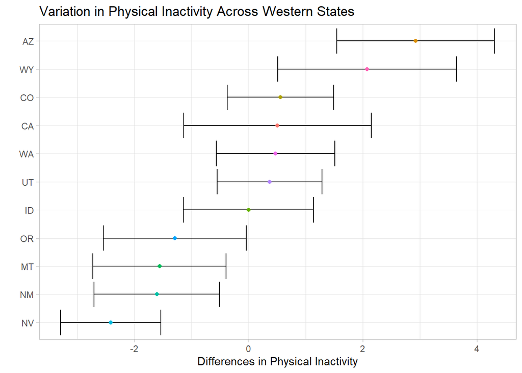

```r
main_effects_mixed_df %>%
  ggplot(aes(fct_reorder(state2, main_effects_diff), main_effects_diff)) +
  geom_errorbar(aes(ymin = main_effects_diff + qnorm(0.025)*main_effects_se,
                  ymax = main_effects_diff + qnorm(0.975)*main_effects_se)) +
  geom_point(aes(color = state2)) +
  coord_flip() +
  labs(x = ' ',
     y = 'Differences in Physical Inactivity',
     title = 'Variation in Physical Inactivity Across Western States') +
  theme(legend.position = 'none')
```

While interesting and the fixed effects show significant predictors, there appears a large amount of variation within each state. With so much variation within each state, I decided to check to see if this could be the result of heteroscedasticity in the data.

## Checking for Heterogeneity Within-State Variation

```r
library(nlme)
library(robustlmm)

inactive_model <- nlme::lme(inactivity ~ access + violent_crime + median_income_thousand +
                            rural + air_pollution + not_lat_per,
                           random = ~1 | state,
                          data = west_data,
                          na.action = na.omit,
                          method = 'ML')

opt <- nlmeControl(maxIter = 100, opt = 'nlm')

inactive_model_check <- nlme::lme(inactivity ~ access + violent_crime + median_income_thousand +
                                    rural + air_pollution + not_lat_per,
                                  random = list(state = pdDiag(~ 1)),
                                  weights = varIdent(form = ~ 1 | state),
                                  data = west_data,
                                  na.action = na.omit,
                                  method = 'ML',
                                  control = opt)

summary(inactive_model)
```

```
## Linear mixed-effects model fit by maximum likelihood
##   Data: west_data
##        AIC      BIC    logLik
##   2297.413 2333.667 -1139.706
##
## Random effects:
##  Formula: ~1 | state
##         (Intercept) Residual
## StdDev:    1.633304 3.669296
##
## Fixed effects:  inactivity ~ access + violent_crime + median_income_thousand +      rural + air_pollution + not_lat_per
##                           Value Std.Error  DF    t-value p-value
## (Intercept)            33.24178 1.8942377 398  17.548897  0.0000
## access                 -0.04111 0.0115164 398  -3.569660  0.0004
## violent_crime           0.00298 0.0013636 398   2.188147  0.0292
## median_income_thousand -0.14649 0.0141117 398 -10.380877  0.0000
## rural                   0.02308 0.0081896 398   2.817878  0.0051
## air_pollution           0.10552 0.1112161 398   0.948810  0.3433
## not_lat_per            -0.02436 0.0154817 398  -1.573338  0.1164
##  Correlation:
##                        (Intr) access vlnt_c mdn_n_ rural  ar_pll
## access                 -0.271
## violent_crime          -0.273 -0.044
## median_income_thousand -0.310 -0.211  0.146
## rural                  -0.427  0.449  0.217  0.278
## air_pollution          -0.503 -0.063 -0.068 -0.012  0.187
## not_lat_per            -0.512 -0.192  0.032 -0.192 -0.318  0.212
##
## Standardized Within-Group Residuals:
##         Min          Q1         Med          Q3         Max
## -3.16643824 -0.61912433 -0.01667018  0.55492258  3.05718915
##
## Number of Observations: 415
## Number of Groups: 11
```

```r
summary(inactive_model_check)
```

```
## Linear mixed-effects model fit by maximum likelihood
##   Data: west_data
##        AIC      BIC    logLik
##   2297.701 2374.239 -1129.851
##
## Random effects:
##  Formula: ~1 | state
##         (Intercept) Residual
## StdDev:    1.698232  4.22309
##
## Variance function:
##  Structure: Different standard deviations per stratum
##  Formula: ~1 | state
##  Parameter estimates:
##        CA        AZ        CO        ID        MT        NM        NV        OR
## 1.0000000 1.1849928 0.7504491 0.7748735 0.9272842 1.0850354 0.6909636 0.7035514
##        UT        WA        WY
## 0.8527477 0.7035399 0.8772992
## Fixed effects:  inactivity ~ access + violent_crime + median_income_thousand +      rural + air_pollution + not_lat_per
##                           Value Std.Error  DF    t-value p-value
## (Intercept)            33.58311 1.8641735 398  18.015015  0.0000
## access                 -0.03971 0.0111285 398  -3.567878  0.0004
## violent_crime           0.00221 0.0013453 398   1.639974  0.1018
## median_income_thousand -0.15095 0.0136549 398 -11.054861  0.0000
## rural                   0.02737 0.0076969 398   3.555982  0.0004
## air_pollution           0.12147 0.1137036 398   1.068286  0.2860
## not_lat_per            -0.02777 0.0155895 398  -1.781276  0.0756
##  Correlation:
##                        (Intr) access vlnt_c mdn_n_ rural  ar_pll
## access                 -0.267
## violent_crime          -0.255 -0.034
## median_income_thousand -0.272 -0.207  0.080
## rural                  -0.400  0.461  0.194  0.254
## air_pollution          -0.503 -0.053 -0.084 -0.018  0.198
## not_lat_per            -0.527 -0.192  0.063 -0.205 -0.326  0.186
##
## Standardized Within-Group Residuals:
##         Min          Q1         Med          Q3         Max
## -2.65141853 -0.66282168 -0.01035039  0.60690603  2.65499620
##
## Number of Observations: 415
## Number of Groups: 11
```

```r
model_compare <- anova(inactive_model, inactive_model_check)
p_value <- model_compare$`p-value`[2]
```

It appears that there is significant differences between counties for each state (*p* = 0.032). Therefore, it is not appropriate to compare states as a random effect. Therefore, using a spatial regression while accounting for states may be more appropriate.

## Cleaning Up Empty Polygons and Preparing Data for Spatial Analyses

```r
poly_join <- west_data %>%
  drop_na() %>% #remove counties with anything missing
  rowid_to_column() %>%
  st_sf()

poly_join <- poly_join[!st_is_empty(poly_join), ]

spatial_join <- as(poly_join, 'Spatial')

set.seed(123021)
poly_nb <- poly2nb(spatial_join, row.names = spatial_join$rowid, queen = TRUE)
poly_listw <- nb2listw(poly_nb, style = "W", zero.policy = TRUE)
summary(poly_listw, zero.policy = TRUE)
```

```
## Characteristics of weights list object:
## Neighbour list object:
## Number of regions: 413
## Number of nonzero links: 2292
## Percentage nonzero weights: 1.343738
## Average number of links: 5.549637
## 1 region with no links:
## 108
## Link number distribution:
##
##  0  1  2  3  4  5  6  7  8  9 10 13 14
##  1  2  9 27 78 88 97 57 39 11  2  1  1
## 2 least connected regions:
## 81 91 with 1 link
## 1 most connected region:
## 16 with 14 links
##
## Weights style: W
## Weights constants summary:
##     n     nn  S0       S1       S2
## W 412 169744 412 158.3648 1693.666
```

## Checking Correlations of Predictors

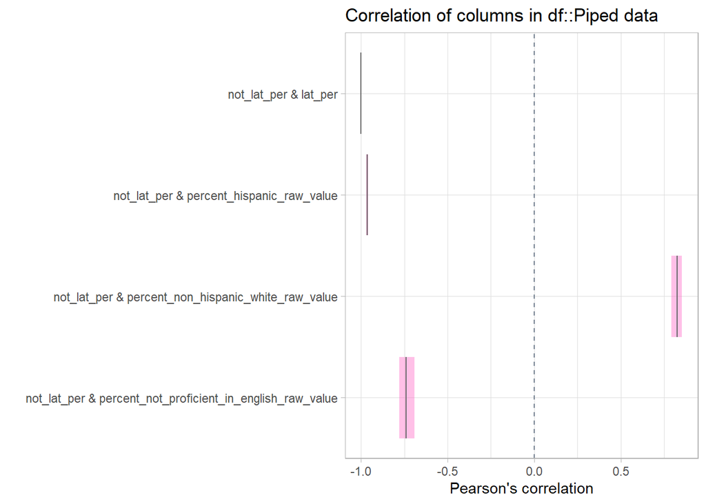

```r
west_data %>%
  inspect_cor(with_col = 'not_lat_per') %>%
  rowid_to_column() %>%
  filter(rowid %in% c(1:4)) %>%
  show_plot()
```

For analyses, I’m only going to examine the `not_lat_per` variable in the model.

```r
activity_model <-
  inactivity ~
  access +
  violent_crime +
  median_income_thousand +
  rural +
  air_pollution +
  not_lat_per +
  state

activity_int_model <-
  inactivity ~
  access*violent_crime +
  median_income_thousand +
  rural +
  air_pollution +
  not_lat_per +
  state
```

```r
set.seed(123021)
ols_main <- lm(activity_model,
              data = spatial_join)
summary(ols_main)
```

```
##
## Call:
## lm(formula = activity_model, data = spatial_join)
##
## Residuals:
##      Min       1Q   Median       3Q      Max
## -11.2270  -2.2669  -0.0823   2.0428  11.0383
##
## Coefficients:
##                         Estimate Std. Error t value             Pr(>|t|)
## (Intercept)            33.925550   2.039184  16.637 < 0.0000000000000002 ***
## access                 -0.039393   0.011595  -3.397             0.000750 ***
## violent_crime           0.003129   0.001407   2.223             0.026775 *
## median_income_thousand -0.147834   0.014255 -10.371 < 0.0000000000000002 ***
## rural                   0.023678   0.008252   2.869             0.004334 **
## air_pollution           0.093587   0.113449   0.825             0.409909
## not_lat_per            -0.028762   0.016264  -1.768             0.077763 .
## stateAZ                 0.263196   1.139389   0.231             0.817436
## stateCO                -2.954433   0.807458  -3.659             0.000288 ***
## stateID                 0.201184   0.879887   0.229             0.819261
## stateMT                 0.300933   0.905013   0.333             0.739674
## stateNM                -2.502678   0.941180  -2.659             0.008153 **
## stateNV                 2.258727   1.076904   2.097             0.036589 *
## stateOR                -0.331978   0.917851  -0.362             0.717776
## stateUT                -1.782656   0.970906  -1.836             0.067096 .
## stateWA                -2.114112   0.874721  -2.417             0.016104 *
## stateWY                 3.164685   1.072041   2.952             0.003345 **
## ---
## Signif. codes:  0 '***' 0.001 '**' 0.01 '*' 0.05 '.' 0.1 ' ' 1
##
## Residual standard error: 3.694 on 396 degrees of freedom
## Multiple R-squared:  0.5145, Adjusted R-squared:  0.4948
## F-statistic: 26.22 on 16 and 396 DF,  p-value: < 0.00000000000000022
```

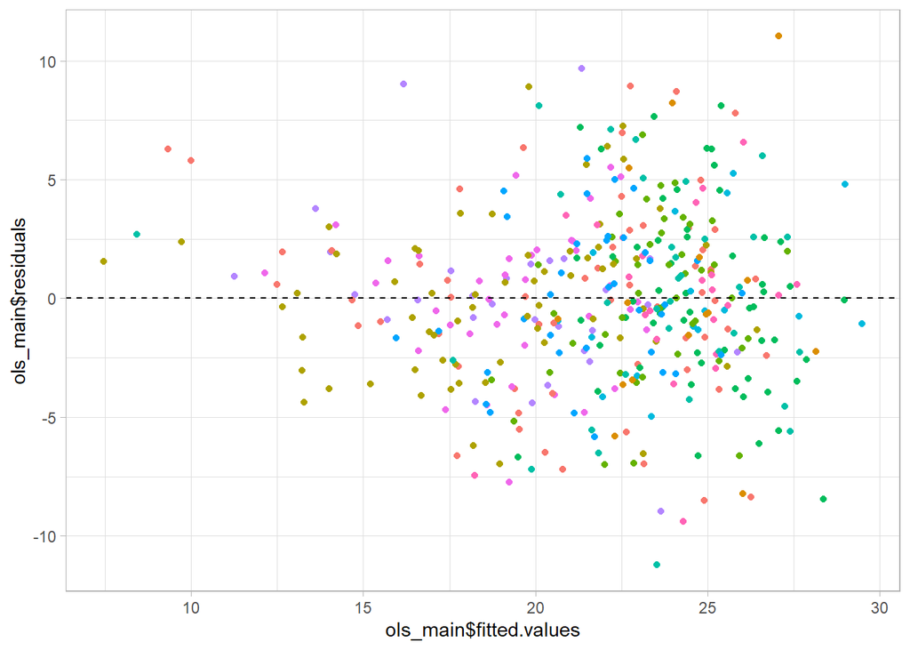

```r
ggplot(data = ols_main, aes(ols_main$fitted.values, ols_main$residuals)) +
  geom_point(aes(color = state)) +
  geom_hline(yintercept = 0,
             color = 'black',
             linetype = 2) +
  theme(legend.position = 'none')
```

```r
moran_resid <- lm.morantest(ols_main,
             poly_listw,
             zero.policy = TRUE,
             alternative = 'two.sided')
moran_resid
```

```
##
##  Global Moran I for regression residuals
##
## data:
## model: lm(formula = activity_model, data = spatial_join)
## weights: poly_listw
##
## Moran I statistic standard deviate = 3.243, p-value = 0.001183
## alternative hypothesis: two.sided
## sample estimates:
## Observed Moran I      Expectation         Variance
##     0.0673289438    -0.0266221166     0.0008392821
```

```r
lagrange_multiplier <- lm.LMtests(ols_main,
           poly_listw,
           test = c("LMerr", "LMlag", "RLMerr", "RLMlag"),
           zero.policy = TRUE)
lagrange_multiplier
```

```
##
##  Lagrange multiplier diagnostics for spatial dependence
##
## data:
## model: lm(formula = activity_model, data = spatial_join)
## weights: poly_listw
##
## LMerr = 4.8825, df = 1, p-value = 0.02713
##
##
##  Lagrange multiplier diagnostics for spatial dependence
##
## data:
## model: lm(formula = activity_model, data = spatial_join)
## weights: poly_listw
##
## LMlag = 4.2962, df = 1, p-value = 0.0382
##
##
##  Lagrange multiplier diagnostics for spatial dependence
##
## data:
## model: lm(formula = activity_model, data = spatial_join)
## weights: poly_listw
##
## RLMerr = 0.8723, df = 1, p-value = 0.3503
##
##
##  Lagrange multiplier diagnostics for spatial dependence
##
## data:
## model: lm(formula = activity_model, data = spatial_join)
## weights: poly_listw
##
## RLMlag = 0.28597, df = 1, p-value = 0.5928
```

```r
sem_main <- errorsarlm(activity_model,
                      data = spatial_join,
                      listw = poly_listw,
                      zero.policy = TRUE)
summary(sem_main,
        Nagalkerke = TRUE,
        zstats = TRUE)
```

```
##
## Call:
## errorsarlm(formula = activity_model, data = spatial_join, listw = poly_listw,
##     zero.policy = TRUE)
##
## Residuals:
##        Min         1Q     Median         3Q        Max
## -11.024860  -2.235265  -0.056977   2.105245  10.670038
##
## Type: error
## Regions with no neighbours included:
##  108
## Coefficients: (asymptotic standard errors)
##                          Estimate Std. Error z value              Pr(>|z|)
## (Intercept)            33.6793736  2.0978584 16.0542 < 0.00000000000000022
## access                 -0.0358967  0.0113471 -3.1635             0.0015589
## violent_crime           0.0034004  0.0013752  2.4726             0.0134122
## median_income_thousand -0.1461161  0.0146858 -9.9495 < 0.00000000000000022
## rural                   0.0272693  0.0080837  3.3734             0.0007425
## air_pollution           0.0660829  0.1158362  0.5705             0.5683484
## not_lat_per            -0.0314746  0.0165798 -1.8984             0.0576464
## stateAZ                 0.5180733  1.2613498  0.4107             0.6812711
## stateCO                -2.9495136  0.8911087 -3.3099             0.0009332
## stateID                 0.3709884  0.9651028  0.3844             0.7006797
## stateMT                 0.3039172  0.9897285  0.3071             0.7587891
## stateNM                -2.5603393  1.0442259 -2.4519             0.0142103
## stateNV                 2.3354815  1.1665417  2.0021             0.0452787
## stateOR                -0.2564561  1.0013341 -0.2561             0.7978625
## stateUT                -1.7878652  1.0629298 -1.6820             0.0925657
## stateWA                -2.1060716  0.9697940 -2.1717             0.0298806
## stateWY                 3.0917317  1.1713646  2.6394             0.0083046
##
## Lambda: 0.16673, LR test value: 4.7021, p-value: 0.030126
## Asymptotic standard error: 0.07438
##     z-value: 2.2415, p-value: 0.024992
## Wald statistic: 5.0244, p-value: 0.024992
##
## Log likelihood: -1114.713 for error model
## ML residual variance (sigma squared): 12.871, (sigma: 3.5876)
## Number of observations: 413
## Number of parameters estimated: 19
## AIC: 2267.4, (AIC for lm: 2270.1)
```

```r
spatial_stand_coef(sem_main)
```

```
##                               [,1]
## (Intercept)             0.00000000
## access                 -0.14886990
## violent_crime           0.11161340
## median_income_thousand -0.46005009
## rural                   0.17650270
## air_pollution           0.02661643
## not_lat_per            -0.10368366
## stateAZ                 0.01866873
## stateCO                -0.20558410
## stateID                 0.02204633
## stateMT                 0.02004102
## stateNM                -0.13184735
## stateNV                 0.08936859
## stateOR                -0.01393386
## stateUT                -0.08799050
## stateWA                -0.11862539
## stateWY                 0.13656344
```

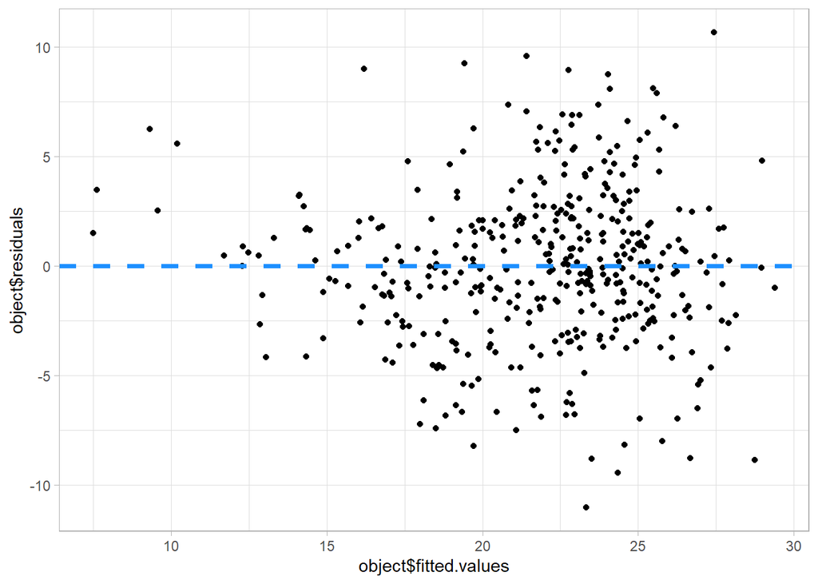

```
##
## [[2]]
## [1] 0.9464
```

```r
error_model_residuals(data = poly_join,
                      object = sem_main,
                      listw = poly_listw,
                      zero.policy = TRUE,
                      nsim = 9999,
                      seed = 123021)
```

For this initial model, we can see that the linear regression shows evidence of spatial autocorrelation in the residuals($\epsilon_i$ = 0.067, p = 0.001). When comparing what spatial regression to use with a Lagrange Multiplier test, we see that the spatial error model may be the most accurate (LMerr = 4.883, p = 0.027) compared to the spatial lag model (Lmlag = 4.296, p = 0.038) so we’ll use a spatial error model. Using a spatial error model accounted for the spatial autocorrelation, so we can use the model and finding.

### Table of Coefficients From Spatial Error Model

```r
library(broom)
library(reactable)
library(htmltools)

summary(sem_main)
```

```
##
## Call:
## errorsarlm(formula = activity_model, data = spatial_join, listw = poly_listw,
##     zero.policy = TRUE)
##
## Residuals:
##        Min         1Q     Median         3Q        Max
## -11.024860  -2.235265  -0.056977   2.105245  10.670038
##
## Type: error
## Regions with no neighbours included:
##  108
## Coefficients: (asymptotic standard errors)
##                          Estimate Std. Error z value              Pr(>|z|)
## (Intercept)            33.6793736  2.0978584 16.0542 < 0.00000000000000022
## access                 -0.0358967  0.0113471 -3.1635             0.0015589
## violent_crime           0.0034004  0.0013752  2.4726             0.0134122
## median_income_thousand -0.1461161  0.0146858 -9.9495 < 0.00000000000000022
## rural                   0.0272693  0.0080837  3.3734             0.0007425
## air_pollution           0.0660829  0.1158362  0.5705             0.5683484
## not_lat_per            -0.0314746  0.0165798 -1.8984             0.0576464
## stateAZ                 0.5180733  1.2613498  0.4107             0.6812711
## stateCO                -2.9495136  0.8911087 -3.3099             0.0009332
## stateID                 0.3709884  0.9651028  0.3844             0.7006797
## stateMT                 0.3039172  0.9897285  0.3071             0.7587891
## stateNM                -2.5603393  1.0442259 -2.4519             0.0142103
## stateNV                 2.3354815  1.1665417  2.0021             0.0452787
## stateOR                -0.2564561  1.0013341 -0.2561             0.7978625
## stateUT                -1.7878652  1.0629298 -1.6820             0.0925657
## stateWA                -2.1060716  0.9697940 -2.1717             0.0298806
## stateWY                 3.0917317  1.1713646  2.6394             0.0083046
##
## Lambda: 0.16673, LR test value: 4.7021, p-value: 0.030126
## Asymptotic standard error: 0.07438
##     z-value: 2.2415, p-value: 0.024992
## Wald statistic: 5.0244, p-value: 0.024992
##
## Log likelihood: -1114.713 for error model
## ML residual variance (sigma squared): 12.871, (sigma: 3.5876)
## Number of observations: 413
## Number of parameters estimated: 19
## AIC: 2267.4, (AIC for lm: 2270.1)
```

```r
sem_main %>%
  tidy() %>%
  mutate(estimate = round(estimate, 3),
         std.error = round(std.error, 3),
         statistic = round(statistic, 3),
         p.value = round(p.value, 3)) %>%
  reactable(highlight = TRUE)
```

| term | estimate | std.error | statistic | p.value |
| --- | --- | --- | --- | --- |
| (Intercept) | 33.679 | 2.098 | 16.054 | 0 |
| access | -0.036 | 0.011 | -3.163 | 0.002 |
| violent_crime | 0.003 | 0.001 | 2.473 | 0.013 |
| median_income_thousand | -0.146 | 0.015 | -9.949 | 0 |
| rural | 0.027 | 0.008 | 3.373 | 0.001 |
| air_pollution | 0.066 | 0.116 | 0.57 | 0.568 |
| not_lat_per | -0.031 | 0.017 | -1.898 | 0.058 |
| stateAZ | 0.518 | 1.261 | 0.411 | 0.681 |
| stateCO | -2.95 | 0.891 | -3.31 | 0.001 |
| stateID | 0.371 | 0.965 | 0.384 | 0.701 |

[output cut: 8 more lines]

```r
set.seed(123021)
ols_int <- lm(activity_int_model,
              data = spatial_join)
summary(ols_int)
```

```
##
## Call:
## lm(formula = activity_int_model, data = spatial_join)
##
## Residuals:
##      Min       1Q   Median       3Q      Max
## -10.9567  -2.3133  -0.0635   2.0600  10.8329
##
## Coefficients:
##                           Estimate  Std. Error t value             Pr(>|t|)
## (Intercept)            33.08602355  2.12123884  15.598 < 0.0000000000000002 ***
## access                 -0.02553416  0.01516582  -1.684             0.093036 .
## violent_crime           0.00776891  0.00356724   2.178             0.030008 *
## median_income_thousand -0.14744154  0.01423963 -10.354 < 0.0000000000000002 ***
## rural                   0.02264859  0.00827380   2.737             0.006473 **
## air_pollution           0.10128107  0.11343628   0.893             0.372484
## not_lat_per            -0.02838439  0.01624578  -1.747             0.081382 .
## stateAZ                 0.24925046  1.13799123   0.219             0.826742
## stateCO                -3.06598601  0.81028020  -3.784             0.000178 ***
## stateID                 0.10741212  0.88126964   0.122             0.903053
## stateMT                 0.26384534  0.90424854   0.292             0.770605
## stateNM                -2.64566246  0.94540465  -2.798             0.005387 **
## stateNV                 2.09789946  1.08152975   1.940             0.053121 .
## stateOR                -0.47526886  0.92226532  -0.515             0.606612
## stateUT                -1.92850271  0.97513999  -1.978             0.048661 *
## stateWA                -2.23230802  0.87759804  -2.544             0.011350 *
## stateWY                 3.02490102  1.07523205   2.813             0.005149 **
## access:violent_crime   -0.00006900  0.00004875  -1.415             0.157783
## ---
## Signif. codes:  0 '***' 0.001 '**' 0.01 '*' 0.05 '.' 0.1 ' ' 1
##
## Residual standard error: 3.69 on 395 degrees of freedom
## Multiple R-squared:  0.5169, Adjusted R-squared:  0.4961
## F-statistic: 24.86 on 17 and 395 DF,  p-value: < 0.00000000000000022
```

```r
lm.morantest(ols_int,
             poly_listw,
             zero.policy = TRUE,
             alternative = 'two.sided')
```

```
##
##  Global Moran I for regression residuals
##
## data:
## model: lm(formula = activity_int_model, data = spatial_join)
## weights: poly_listw
##
## Moran I statistic standard deviate = 3.5688, p-value = 0.0003586
## alternative hypothesis: two.sided
## sample estimates:
## Observed Moran I      Expectation         Variance
##     0.0769175940    -0.0264754744     0.0008393395
```

```r
lm.LMtests(ols_int,
           poly_listw,
           test = c("LMerr", "LMlag", "RLMerr", "RLMlag"),
           zero.policy = TRUE)
```

```
##
##  Lagrange multiplier diagnostics for spatial dependence
##
## data:
## model: lm(formula = activity_int_model, data = spatial_join)
## weights: poly_listw
##
## LMerr = 6.3722, df = 1, p-value = 0.01159
##
##
##  Lagrange multiplier diagnostics for spatial dependence
##
## data:
## model: lm(formula = activity_int_model, data = spatial_join)
## weights: poly_listw
##
## LMlag = 4.7081, df = 1, p-value = 0.03002
##
##
##  Lagrange multiplier diagnostics for spatial dependence
##
## data:
## model: lm(formula = activity_int_model, data = spatial_join)
## weights: poly_listw
##
## RLMerr = 1.7461, df = 1, p-value = 0.1864
##
##
##  Lagrange multiplier diagnostics for spatial dependence
##
## data:
## model: lm(formula = activity_int_model, data = spatial_join)
## weights: poly_listw
##
## RLMlag = 0.08197, df = 1, p-value = 0.7746
```

```r
sem_int <- errorsarlm(activity_int_model,
                      data = spatial_join,
                      listw = poly_listw,
                      zero.policy = TRUE)
summary(sem_int,
        Nagalkerke = TRUE,
        zstats = TRUE)
```

```
##
## Call:errorsarlm(formula = activity_int_model, data = spatial_join,
##     listw = poly_listw, zero.policy = TRUE)
##
## Residuals:
##        Min         1Q     Median         3Q        Max
## -10.679888  -2.238971  -0.098412   2.096388  10.355500
##
## Type: error
## Regions with no neighbours included:
##  108
## Coefficients: (asymptotic standard errors)
##                            Estimate   Std. Error z value              Pr(>|z|)
## (Intercept)            32.520859124  2.182725318 14.8992 < 0.00000000000000022
## access                 -0.016750234  0.014726257 -1.1374             0.2553544
## violent_crime           0.009604267  0.003417760  2.8101             0.0049525
## median_income_thousand -0.145901570  0.014752619 -9.8899 < 0.00000000000000022
## rural                   0.026535663  0.008076008  3.2857             0.0010171
## air_pollution           0.073822752  0.116314154  0.6347             0.5256344
## not_lat_per            -0.031780829  0.016619864 -1.9122             0.0558480
## stateAZ                 0.568493490  1.284795424  0.4425             0.6581435
## stateCO                -3.063515254  0.910137564 -3.3660             0.0007627
## stateID                 0.314217784  0.983216017  0.3196             0.7492855
## stateMT                 0.290197082  1.006828477  0.2882             0.7731715
## stateNM                -2.772740087  1.069845246 -2.5917             0.0095497
## stateNV                 2.210572924  1.185215729  1.8651             0.0621642
## stateOR                -0.402070259  1.021080532 -0.3938             0.6937513
## stateUT                -1.942435614  1.084048897 -1.7918             0.0731596
## stateWA                -2.232942708  0.990999660 -2.2532             0.0242451
## stateWY                 2.920894991  1.193481723  2.4474             0.0143902
## access:violent_crime   -0.000091019  0.000046303 -1.9657             0.0493336
##
## Lambda: 0.19507, LR test value: 6.3184, p-value: 0.011949
## Asymptotic standard error: 0.073322
##     z-value: 2.6605, p-value: 0.0078034
## Wald statistic: 7.078, p-value: 0.0078034
##
## Log likelihood: -1112.86 for error model
## ML residual variance (sigma squared): 12.731, (sigma: 3.568)
## Number of observations: 413
## Number of parameters estimated: 20
## AIC: 2265.7, (AIC for lm: 2270)
```

```r
spatial_stand_coef(sem_int)
```

```
##                               [,1]
## (Intercept)             0.00000000
## access                 -0.06946619
## violent_crime           0.31525055
## median_income_thousand -0.45937470
## rural                   0.17175428
## air_pollution           0.02973384
## not_lat_per            -0.10469235
## stateAZ                 0.02048562
## stateCO                -0.21353013
## stateID                 0.01867268
## stateMT                 0.01913628
## stateNM                -0.14278516
## stateNV                 0.08458889
## stateOR                -0.02184541
## stateUT                -0.09559775
## stateWA                -0.12577146
## stateWY                 0.12901749
## access:violent_crime   -0.24277393
```

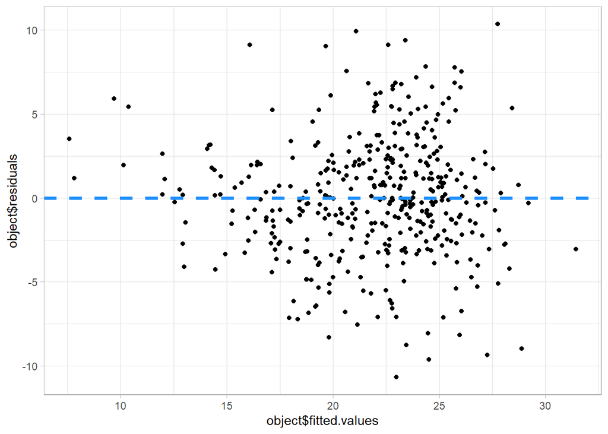

```
##
## [[2]]
## [1] 0.9182
```

```r
error_model_residuals(data = poly_join,
                      object = sem_int,
                      listw = poly_listw,
                      zero.policy = TRUE,
                      nsim = 9999,
                      seed = 123021)
```

### Table of Coefficients From Spatial Error Model w/ Interaction & Johnson-Neyman Intervals Plot

```r
sem_int %>%
  tidy() %>%
  mutate(estimate = round(estimate, 3),
         std.error = round(std.error, 3),
         statistic = round(statistic, 3),
         p.value = round(p.value, 3)) %>%
  reactable(highlight = TRUE)
```

| term | estimate | std.error | statistic | p.value |
| --- | --- | --- | --- | --- |
| (Intercept) | 32.521 | 2.183 | 14.899 | 0 |
| access | -0.017 | 0.015 | -1.137 | 0.255 |
| violent_crime | 0.01 | 0.003 | 2.81 | 0.005 |
| median_income_thousand | -0.146 | 0.015 | -9.89 | 0 |
| rural | 0.027 | 0.008 | 3.286 | 0.001 |
| air_pollution | 0.074 | 0.116 | 0.635 | 0.526 |
| not_lat_per | -0.032 | 0.017 | -1.912 | 0.056 |
| stateAZ | 0.568 | 1.285 | 0.442 | 0.658 |
| stateCO | -3.064 | 0.91 | -3.366 | 0.001 |
| stateID | 0.314 | 0.983 | 0.32 | 0.749 |

[output cut: 9 more lines]

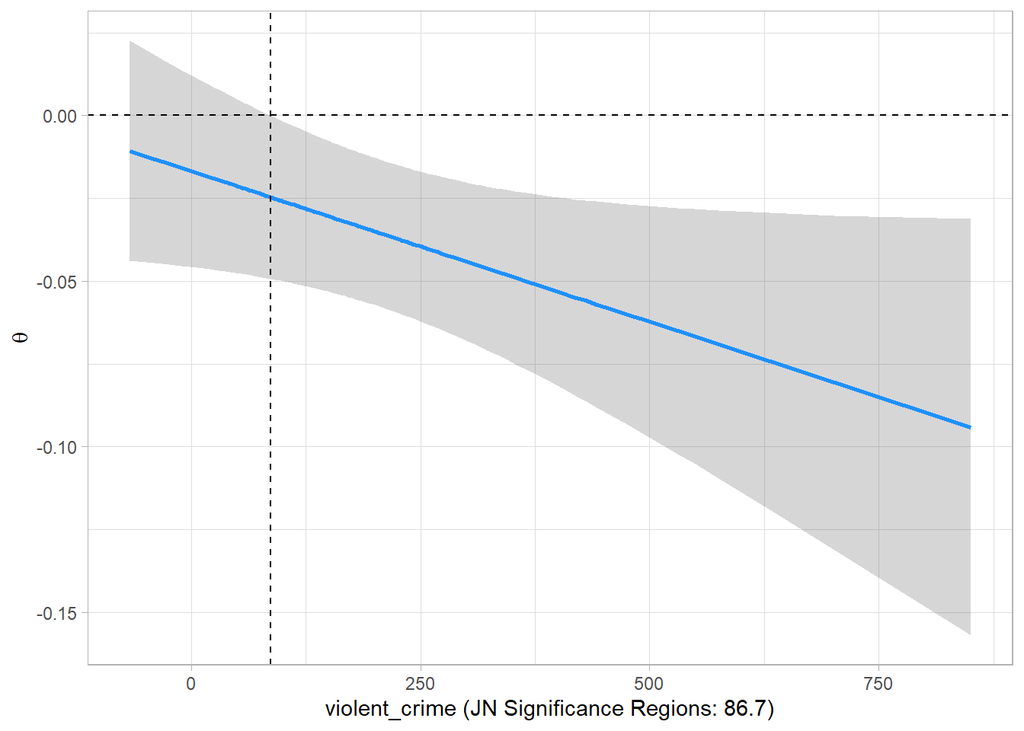

```r
theta_plot_sem(sem_int,
               x = 'access',
               m = 'violent_crime',
               jn = TRUE)[2]
```